# Part II - Factors Influencing the Outcome of a Loan Amount

## by Ashley Muthoni

## Investigation Overview

My goal during the investigation was to look at the factors that influence how much money a borrower can be issued in relation to its monthly payment. I wanted to look at the categoric variiables of loan status, employment status and loan term as well as additional factors like the lender yield and income range.

Even with the loan amount and its monthly payment having a strong positive correlation, borrowers wtih favourable employment statuses seem to also ocassionaly face uncertainity in remitting payments towards their higher-priced loans. It was interesting to note that borrowers who take out lower loan amounts in the 12 month term were at more at risk of also being deliquent or being in default.

## Dataset Overview

The dataset consisted of the original loan amounts and other related attributes of 113937 loans. The attributes included the loan amount and its monthly payment, loan status, employment status, term, income range and its verification. Fifty-eight variables were eliminated because of missing values and their relevance to the analysis.

## Distribution of Loan Amount

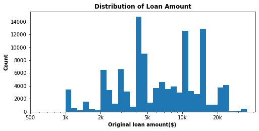

## Distribution of Monthly Loan Payment

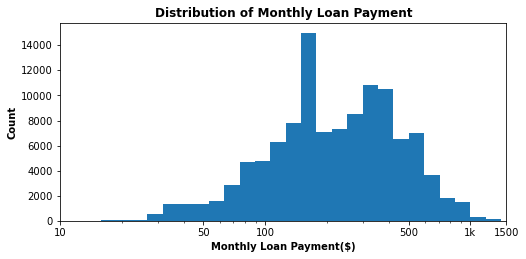

## Monthly Loan Payment by Loan Status and Term for Selected Loan Amounts

We can see how monthly loan payments differs across loan status for different loan terms on selected loan amounts: those on the upper end from $10,000 to $15,000 and lower ends of $1000 to $5000. For both upper and lower amounts, as the longer loan terms effects a decreased monthly loan payment.

For loans ranging from those current to the defaulted and chargedoff, it is more favorable to take long-term loans of 60 months. This has lower risk levels for borrowers regardless of the loan amount they apply for.

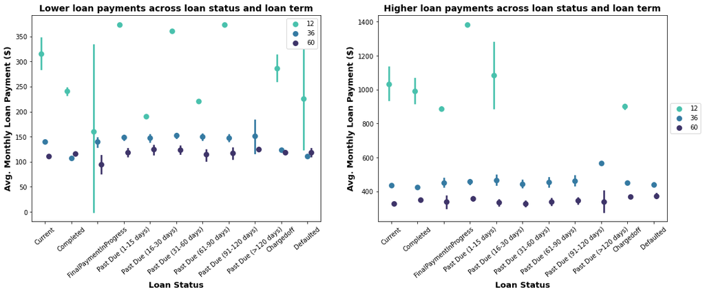

## Monthly Loan Payment by Employment Status and Term for Selected Loan Amounts

Reproducing the same plots with Employment Status and Terms instead of Loan Status grade shows the same trend of decreased monthly payments with longer term loans. However despite having an attractive status of being employed, self-employed, full time; contributing to that 12-month loan still has the uncertainity of servicing it. 60-month long term loans still prove to be the most favourable loan outcomes regardless of employment status.

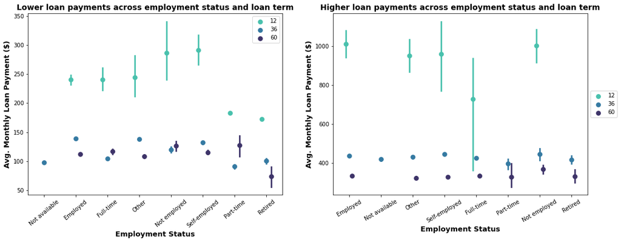

## Loan Amount by Income Range and its Verification

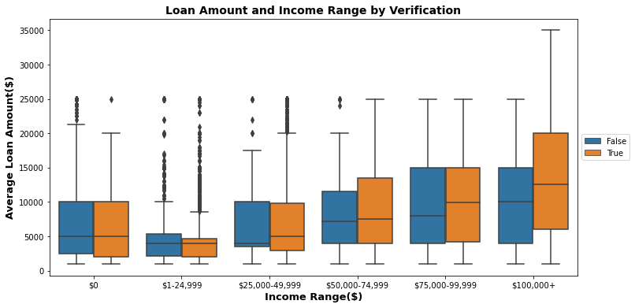

## Loan Amount and Lender Yield by the Investors of random sample

High loan amounts are not necessarily funded by more investors as even fewer investors still fund high-end loan amounts. There appears to be a minimum loan amount of $1000. This funding however, does not automatically translate to higher returns from the investment for the investors because of other factors surrounding the structuring of the loan.

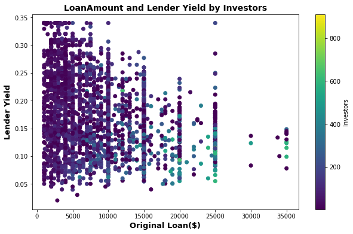

[output not shown]

[output cut: 42 more lines]

[output not shown]

[output not shown]

[output not shown]

[output cut: 27 more lines]

[output not shown]